# ANOVA - R, JAGS, Simulation, Fixed/Random

## Introduction

Anova is used for comparing means of 2 or more groups. It is a generalization of two sample t-test. Assume the data has 5 groups with different means. The goal is to test if the group means are different (at some significance level). Note: ANOVA/F-test can be used to test if model terms are significant (above ex) or test many models against one another (all models fitted on same data). For more information about F-statistic and computation refer this [wiki page](https://en.wikipedia.org/wiki/F-test)

## Regression Model Comparison using ANOVA

Consider regression models with increasing model complexity. Assuming the models are nested (with increasing addition of variables), we can compare the models using `anova` function. This function compares consecutive models with results showing improvement in squared errors and corresponding p-values. In the below example, `lm1` shows significant improvement over `lm0`. While there is improvement from `lm1` to `lm2`, it is not significant.

```r
lm0 <- lm(dist ~ 1, cars)
lm1 <- lm(dist ~ speed, cars)
lm2 <- lm(dist ~ speed + I(speed^2), cars)

anova(lm0, lm1, lm2)
```

```
## Analysis of Variance Table
##
## Model 1: dist ~ 1
## Model 2: dist ~ speed
## Model 3: dist ~ speed + I(speed^2)
##   Res.Df   RSS Df Sum of Sq      F    Pr(>F)
## 1     49 32539
## 2     48 11354  1   21185.5 91.986 1.211e-12 ***
## 3     47 10825  1     528.8  2.296    0.1364
## ---
## Signif. codes:  0 '***' 0.001 '**' 0.01 '*' 0.05 '.' 0.1 ' ' 1
```

## Multiple Comparison of Group Means

Consider several groups with constant variance. The goal is to check if group means are same.

```r
ngroups <- 5 # Number of groups / treatments
nsample <- 10 # Number of observations in each group
n <- ngroups*nsample # Total number of data points

pop.means <- c(50, 40, 45, 55, 60) # Population means for each of the groups
normal.error <- rnorm(n, 0, 3) # Residuals, Residual sd=3 (note: assumption of homoscedasticity)

x <- as.factor(rep(1:5, rep(nsample, ngroups))) # Indicator for group
y <- rep(pop.means, each=nsample) + normal.error
```

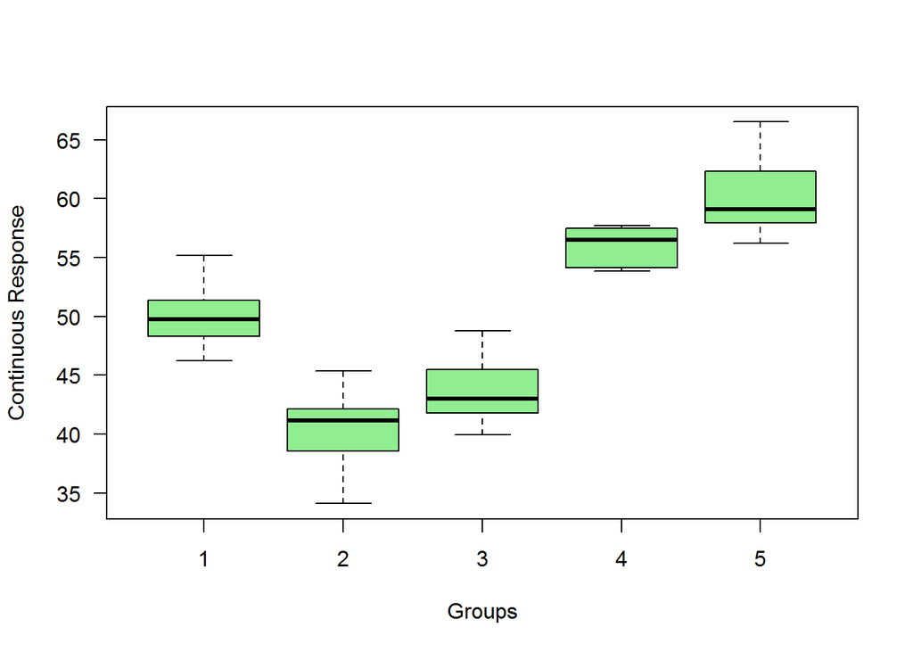

## ANOVA using base R

ANOVA can be done using

```r
anova(lm(y~x))
```

```
## Analysis of Variance Table
##
## Response: y
##           Df  Sum Sq Mean Sq F value    Pr(>F)
## x          4 2623.03  655.76  84.652 < 2.2e-16 ***
## Residuals 45  348.59    7.75
## ---
## Signif. codes:  0 '***' 0.001 '**' 0.01 '*' 0.05 '.' 0.1 ' ' 1
```

## ANOVA in JAGS

```r
m <- "model {
  # Likelihood
  for (i in 1:(ngroups*nsample)) {
    y[i] ~ dnorm(means[x[i]], tau)
  }

  # Priors
  for (i in 1:ngroups) {
    means[i] ~ dnorm(0, 0.001)
  }

  sigma ~ dunif(0,100)
  tau <- 1/(sigma*sigma)

  # output variables
  for (i in 1:(ngroups-1)) {
    effect[i] <- means[i+1] - means[i]
  }
}"
mean.diff <- list('x'=as.numeric(x),'y'=y,'ngroups'=ngroups,'nsample'=nsample) %>%
             jags.model(file = textConnection(m), data = ., n.adapt = 1000) %>%
             jags.samples(c('effect'), 100) %>% `$`(effect) %>%
             matrix(ncol=4, byrow=T) %>% colMeans %>% round(1)
```

```
##              mean.diff
## Group 1 vs 2      -9.5
## Group 2 vs 3       3.1
## Group 3 vs 4      12.1
## Group 4 vs 5       4.1
```

## ANOVA by Permutation Test

The statistic F is defined by:
$$F = \frac{between-group-variability}{within-group-variability}$$
For permutation test, the `F` value for original dataset is computed. The dataset is then shuffled and and several `F` values are computed. The proportion of `F` values above the reference is the p-value.

```r
between.group.var <- function(x,y) {sum(nsample*(sapply(1:ngroups, function(i) {mean(y[x==i])}) - mean(y))^2)/(ngroups-1)}
within.group.var  <- function(x,y) {sum((y-rep(sapply(1:ngroups, function(i) {mean(y[x==i])}),each=nsample))^2)/(n-ngroups)}
F.Statistic       <- function(x,y) {between.group.var(x,y) / within.group.var(x,y)}

F.orig <- F.Statistic(x,y)

Fs <- replicate(10000, F.Statistic(x, sample(y)))

cat("p-value is ", mean(Fs > F.orig))
```

```
## p-value is  0
```

## ANOVA for Random Effects

Random effects: the means for the different groups are correlated and they come from a probability distribution. In contrast to fixed-effects ANOVA, where they are taken to be independent AND fixed / not variable, e.g., the treatments are the entire population, i.e., they exhaust the space of all treatments

Note that the stochastic part of the model consists of TWO stochastic processes:

- the usual one involving the probability distribution for individual observations (normal.error)
- the one involving the probability distribution for the group means (the random effects)

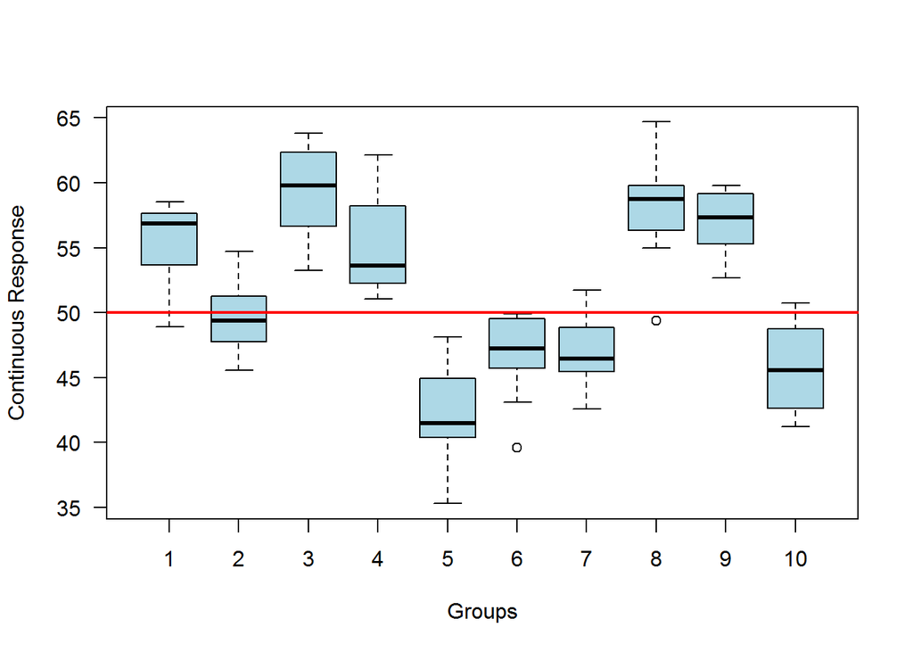

```r
npop <- 10 # Number of groups
nsample <- 12 # Number of observations in each group
n <- npop*nsample   # Total number of data points

pop.grand.mean <- 50 # Grand mean
pop.sd <- 5 # sd of population effects about mean
pop.means <- rnorm(n=npop, mean=pop.grand.mean, sd=pop.sd)
normal.error <- rnorm(n, 0, 3);sigma=3 # Draw residuals with residual sd=3

x <- rep(1:npop, rep(nsample, npop))
X <- as.matrix(model.matrix(~as.factor(x)-1))

y <- as.numeric(X %*% as.matrix(pop.means) + normal.error) # recall that as.numeric is essential

boxplot(y~x, col="lightblue", xlab="Groups", ylab="Continuous Response", main="", las=1)
abline(h=pop.grand.mean, col="red", lwd=2)
```

```r
library("lme4")
pop <- as.factor(x) # Define x as a factor and call it pop
lme.fit <- lmer(y~1+1|pop) %>% summary()
```

[output not shown]